# Teoria de Estoques e Simulação de Processos de Chegada com Distribuição de Poisson

Bruna Cruz Siqueira

`05-08-2025

# Teoria de Estoques e Simulação de Processos de Chegada com Distribuição de Poisson

## 1. Introdução

A gestão eficiente de estoques é um pilar fundamental para o sucesso de qualquer organização que lida com produtos físicos, seja na manufatura, varejo ou serviços. Em um ambiente de negócios cada vez mais dinâmico e incerto, a capacidade de otimizar os níveis de estoque impacta diretamente a lucratividade, a satisfação do cliente e a competitividade. A **Teoria de Estoques** fornece as ferramentas e modelos matemáticos necessários para tomar decisões informadas sobre quando e quanto pedir, minimizando custos e garantindo a disponibilidade de produtos [1].

No entanto, muitos dos desafios reais na gestão de estoques envolvem a variabilidade e a incerteza, características inerentes a processos estocásticos como a demanda de clientes e o tempo de reposição de produtos. Nesses cenários, a **simulação computacional** emerge como uma metodologia poderosa para analisar o comportamento de sistemas complexos, testar diferentes políticas de estoque e prever seu desempenho sob diversas condições, sem a necessidade de intervir no sistema real [2]. Este artigo acadêmico explora a intersecção entre a Teoria de Estoques e a simulação de processos de chegada, com foco na Distribuição de Poisson, fornecendo uma fundamentação teórica robusta e diretrizes para a modelagem em simulações.

## 2. Fundamentação Teórica

### 2.1. Teoria de Estoques

A Teoria de Estoques busca equilibrar os custos associados à manutenção de estoques com os custos de não ter estoque suficiente para atender à demanda. Os modelos clássicos de estoque são a base para a compreensão e otimização dessa balança [3].

#### 2.1.1. Modelos Clássicos

O **Modelo de Lote Econômico de Compra (EOQ - Economic Order Quantity)** é um dos modelos mais fundamentais, que determina a quantidade ótima de pedido que minimiza a soma dos custos de pedido e de manutenção. A fórmula do EOQ é dada por:

$$EOQ = \sqrt{\frac{2DS}{H}}$$

Onde: * $D$ = Demanda anual * $S$ = Custo por pedido * $H$ = Custo de manutenção por unidade por ano

Outros modelos importantes incluem os **modelos com ponto de ressuprimento (ROP - Reorder Point)**, que disparam um novo pedido quando o nível de estoque atinge um ponto pré-determinado, e os sistemas de **revisão contínua (Q-system)** e **revisão periódica (P-system)**. No sistema Q, o estoque é monitorado continuamente e um pedido de tamanho fixo é feito quando o ROP é atingido. No sistema P, o estoque é revisado em intervalos fixos e um pedido de tamanho variável é feito para elevar o estoque a um nível alvo [4].

#### 2.1.2. Custos Envolvidos

Os principais custos na gestão de estoques são:

- **Custo de Pedido (Ordering Cost):** Associado à emissão e processamento de um pedido, incluindo custos administrativos, de transporte e de recebimento.
- **Custo de Manutenção (Holding Cost):** Relacionado à posse do estoque, incluindo capital empatado, armazenagem, obsolescência, seguro e perdas.
- **Custo de Falta (Shortage Cost):** Decorrente da incapacidade de atender à demanda, podendo ser perda de vendas, insatisfação do cliente ou custos de produção acelerada [3].

#### 2.1.3. Tipos de Demanda e Lead Time

A demanda pode ser **determinística**, quando é conhecida e constante, ou **probabilística (estocástica)**, quando varia aleatoriamente. A maioria dos cenários reais envolve demanda probabilística, o que exige o uso de estoque de segurança para mitigar riscos de falta. O **lead time (tempo de reposição)** é o tempo entre a emissão de um pedido e o recebimento do produto. A variabilidade no lead time também é um fator crítico que influencia a necessidade de estoque de segurança [5].

### 2.2. Processos de Chegada com Distribuição de Poisson

Um **Processo de Poisson** é um modelo estocástico que descreve o número de eventos que ocorrem em um intervalo de tempo fixo ou em uma região específica, dado que esses eventos ocorrem com uma taxa média constante e independentemente uns dos outros. É amplamente utilizado para modelar chegadas de clientes em sistemas de fila, ocorrências de falhas em equipamentos, e, crucialmente, a demanda em sistemas de estoque [6].

#### 2.2.1. Propriedades do Processo de Poisson

As principais propriedades de um processo de Poisson com taxa $\lambda$ são:

- **Estacionariedade:** A probabilidade de um evento ocorrer em um intervalo de tempo depende apenas do comprimento do intervalo, não de sua localização no tempo.
- **Independência de Incrementos:** O número de eventos em intervalos de tempo disjuntos são variáveis aleatórias independentes.
- **Distribuição Exponencial dos Tempos Entre Chegadas:** Se o número de chegadas segue uma distribuição de Poisson, então o tempo entre chegadas consecutivas segue uma distribuição exponencial com média $1/\lambda$. A função de densidade de probabilidade (PDF) para o tempo entre chegadas $T$ é:

  $$f(t) = \lambda e^{-\lambda t} \quad
  \text{para } t \ge 0$$
- **Distribuição de Poisson para o Número de Chegadas:** O número de chegadas $N(t)$ em um intervalo de tempo de duração $t$ segue uma distribuição de Poisson com parâmetro $\lambda t$. A função de massa de probabilidade (PMF) é:

  $$P(N(t) = k) = \frac{e^{-\lambda t}
  (\lambda t)^k}{k!} \quad \text{para } k = 0, 1, 2, \dots$$

#### 2.2.2. Aplicações e Relação com Processos de Markov

Processos de Poisson são fundamentais em **Teoria das Filas**, onde modelam a chegada de clientes a um sistema. Em **estoques**, são usados para representar a demanda por itens em períodos de tempo. A simplicidade e as propriedades matemáticas dos processos de Poisson os tornam ideais para simulações de eventos discretos. Além disso, há uma forte relação entre processos de Poisson e **Processos de Markov**, especialmente em cadeias de Markov de tempo contínuo, onde as transições entre estados ocorrem de acordo com taxas exponenciais, análogas aos tempos entre chegadas de Poisson [7].

## 3. Metodologia de Simulação

A simulação de sistemas de estoque com demanda e lead time estocásticos, modelados por processos de Poisson, é uma ferramenta essencial para a análise de desempenho e a tomada de decisões. A linguagem R, com seus pacotes estatísticos e de simulação, é particularmente adequada para essa finalidade.

### 3.1. Modelagem da Chegada de Clientes/Demanda

Para simular a demanda de clientes ou a chegada de pedidos usando um processo de Poisson, o primeiro passo é definir a taxa média de chegada ($\lambda$). Por exemplo, se a demanda média diária é de 10 unidades, então $\lambda = 10$ unidades/dia. A geração de eventos de demanda pode ser feita de duas maneiras principais:

1. **Geração do Número de Eventos em um Intervalo:** Para simular a demanda em um dia, pode-se gerar um número aleatório a partir de uma distribuição de Poisson com parâmetro $\lambda \times 1$ (se $\lambda$ for a taxa diária). Em R, isso pode ser feito com `rpois(n=1, lambda = lambda_diaria)`.
2. **Geração dos Tempos Entre Eventos:** Alternativamente, pode-se gerar os tempos entre chegadas consecutivas usando uma distribuição exponencial com taxa $\lambda$. Em R, `rexp(n=1, rate = lambda)` geraria o tempo até a próxima chegada. A soma desses tempos determinaria quando o próximo evento de demanda ocorreria.

### 3.2. Integração com Modelos de Estoque

A integração da demanda simulada com os modelos de estoque permite avaliar o impacto da variabilidade. Por exemplo, em um sistema de revisão contínua (Q-system), a simulação pode rastrear o nível de estoque ao longo do tempo, registrando quando o ROP é atingido e quando os pedidos são feitos e recebidos. A variabilidade na demanda (modelada por Poisson) e no lead time (que também pode ser modelado por uma distribuição, como a uniforme ou normal, ou até mesmo exponencial) afetará a frequência de pedidos, os níveis de estoque de segurança necessários e a ocorrência de faltas.

Ao simular, é possível coletar métricas de desempenho como:

- Nível médio de estoque
- Número de faltas e seu custo associado
- Número de pedidos e seu custo associado
- Custo total do sistema de estoque

Essas métricas permitem comparar diferentes políticas de estoque (e.g., diferentes ROPs ou tamanhos de pedido) e identificar a que melhor se adapta às condições de demanda e lead time estocásticas. A simulação oferece um ambiente controlado para experimentação, onde os parâmetros do sistema podem ser ajustados e seus efeitos observados sem risco real.

### 3.3 Método de Monte Carlo

O Método de Monte Carlo é uma técnica estocástica utilizada para resolver problemas complexos por meio de simulações baseadas em amostragem aleatória. Trata-se de um método amplamente empregado em diversas áreas da ciência e, particularmente, na simulação computacional de sistemas logísticos e de produção, devido à sua capacidade de modelar incertezas e comportamentos aleatórios de variáveis. Em contextos como o gerenciamento de estoques, o Método de Monte Carlo permite simular diferentes cenários de demanda, lead time e falhas no abastecimento, fornecendo uma visão mais robusta sobre o desempenho de políticas de estoque sob incertezas.

A base do método consiste em repetir um experimento computacional diversas vezes, utilizando números pseudoaleatórios para representar os eventos incertos. Com isso, é possível estimar distribuições, médias, variâncias, probabilidades e outros parâmetros de interesse a partir da análise estatística dos resultados simulados.

Por exemplo, ao se considerar a chegada de pedidos de clientes como um processo de Poisson e o tempo de reposição de estoque como uma variável aleatória (como distribuição exponencial ou uniforme), pode-se utilizar Monte Carlo para avaliar a probabilidade de ruptura de estoque, o nível médio de inventário e o custo total esperado, com base em 1.000 ou mais simulações do ciclo de operação.

## 4 Simulação

### 4.1 Exemplo Simples de Estoque

Simulação computacional simples para representar o comportamento de um sistema de controle de estoque de um único produto, no caso, **água**, ao longo de um período determinado. A simulação desenvolvida não busca reproduzir um sistema real com alta precisão, mas sim oferecer uma abordagem conceitual sobre como variáveis aleatórias como demanda diária, prazo de entrega e frequência de pedidos podem ser incorporadas na modelagem de estoques. Os parâmetros utilizados, como quantidade inicial, limite mínimo para reposição, quantidade a ser reposta, tempo de entrega, entre outros, foram definidos com base em valores arbitrários e plausíveis, escolhidos por bom senso e com a finalidade de tornar o modelo compreensível e funcional.

Essa simulação ilustra a potência do uso de técnicas de simulação estocástica mesmo em contextos iniciais, e destaca como a estatística computacional pode contribuir para a compreensão e análise de fenômenos operacionais em ambientes de incerteza.

```r
# Carregar a biblioteca para gráficos
library(ggplot2)
# Usar set.seed garante que os resultados "aleatórios" sejam os mesmos toda vez
set.seed(666)

# Parâmetros da simulação e do estoque
dias_simulados <- 60
simulacoes <- 1000
lambda_demanda <- 20
lead_time <- 2
ponto_ressuprimento <- 30
quantidade_pedido <- 100
estoque_inicial <- 100

# Parâmetros de Custo
custo_pedido <- 40.00        # Custo fixo por fazer um pedido
custo_holding_unit <- 0.25   # Custo para manter 1 unidade por 1 dia
custo_falta_unit <- 5.00     # Penalidade por faltar 1 unidade quando demandada
custo_unitario_produto <- 8.00   # NOVO: Preço de compra de cada unidade

# --------------------------------------------------------------------------
# 2. DEFINIÇÃO DA FUNÇÃO DE SIMULAÇÃO
# --------------------------------------------------------------------------
simular_estoque_df <- function(dias, lambda, lead, reord_point, qtd_pedido, estoque_ini,
                               cost_order, cost_hold, cost_short) {

  demanda <- rpois(dias, lambda)
  pedidos_em_andamento <- rep(0, dias + lead)
  estoque_atual <- estoque_ini

  # Vetores de dados físicos
  estoque <- numeric(dias)
  pedido_chega <- numeric(dias)
  unidades_faltantes <- numeric(dias)
  pedido_ativo <- FALSE

  # Vetores para armazenar custos diários
  custo_pedido_dia <- numeric(dias)
  custo_holding_dia <- numeric(dias)
  custo_falta_dia <- numeric(dias)

  for (dia in 1:dias) {
    # 1. Receber pedidos que chegam hoje
    estoque_atual <- estoque_atual + pedidos_em_andamento[dia]
    pedido_chega[dia] <- pedidos_em_andamento[dia]
    if (pedidos_em_andamento[dia] > 0) {
      pedido_ativo <- FALSE
    }

    # 2. Atender à demanda e calcular CUSTO DE FALTA
    if (estoque_atual < demanda[dia]) {
      unidades_faltantes[dia] <- demanda[dia] - estoque_atual
      custo_falta_dia[dia] <- unidades_faltantes[dia] * cost_short
    }

    estoque_atual <- estoque_atual - demanda[dia]
    if (estoque_atual < 0) estoque_atual <- 0

    # 3. Registrar estoque final e calcular CUSTO DE MANUTENÇÃO
    estoque[dia] <- estoque_atual
    custo_holding_dia[dia] <- estoque[dia] * cost_hold

    # 4. Verificar reposição e calcular CUSTO DE PEDIDO
    if (estoque_atual <= reord_point && !pedido_ativo) {
      pedidos_em_andamento[dia + lead] <- qtd_pedido
      pedido_ativo <- TRUE
      custo_pedido_dia[dia] <- cost_order
    }
  }

  # Adicionar colunas de custo ao dataframe de resultado
  df <- data.frame(
    Dia = 1:dias,
    Demanda = demanda,
    Estoque = estoque,
    PedidoChega = pedido_chega,
    UnidadesFaltantes = unidades_faltantes,
    CustoPedidoDia = custo_pedido_dia,
    CustoHoldingDia = custo_holding_dia,
    CustoFaltaDia = custo_falta_dia
  )
  return(df)
}

# --------------------------------------------------------------------------
# 3. ANÁLISE DE UMA ÚNICA SIMULAÇÃO
# --------------------------------------------------------------------------
# 3.1. Executando a simulação uma única vez
df_simulacao_unica <- simular_estoque_df(
  dias = dias_simulados, lambda = lambda_demanda, lead = lead_time,
  reord_point = ponto_ressuprimento, qtd_pedido = quantidade_pedido,
  estoque_ini = estoque_inicial, cost_order = custo_pedido,
  cost_hold = custo_holding_unit, cost_short = custo_falta_unit
)

# 3.2. Exibindo a tabela de dados da simulação única
print(summary(df_simulacao_unica))
```

```
##       Dia           Demanda         Estoque       PedidoChega
##  Min.   : 1.00   Min.   :10.00   Min.   : 0.00   Min.   :  0.00
##  1st Qu.:15.75   1st Qu.:17.00   1st Qu.:18.75   1st Qu.:  0.00
##  Median :30.50   Median :20.00   Median :44.00   Median :  0.00
##  Mean   :30.50   Mean   :20.22   Mean   :43.83   Mean   : 18.33
##  3rd Qu.:45.25   3rd Qu.:23.00   3rd Qu.:69.00   3rd Qu.:  0.00
##  Max.   :60.00   Max.   :32.00   Max.   :98.00   Max.   :100.00
##  UnidadesFaltantes CustoPedidoDia CustoHoldingDia  CustoFaltaDia
##  Min.   : 0.0      Min.   : 0     Min.   : 0.000   Min.   : 0.0
##  1st Qu.: 0.0      1st Qu.: 0     1st Qu.: 4.688   1st Qu.: 0.0
##  Median : 0.0      Median : 0     Median :11.000   Median : 0.0
##  Mean   : 0.3      Mean   : 8     Mean   :10.958   Mean   : 1.5
##  3rd Qu.: 0.0      3rd Qu.: 0     3rd Qu.:17.250   3rd Qu.: 0.0
##  Max.   :12.0      Max.   :40     Max.   :24.500   Max.   :60.0
```

```r
print(head(df_simulacao_unica, 10))
```

```
##    Dia Demanda Estoque PedidoChega UnidadesFaltantes CustoPedidoDia
## 1    1      23      77           0                 0              0
## 2    2      29      48           0                 0              0
## 3    3      18      30           0                 0             40
## 4    4      29       1           0                 0              0
## 5    5      10      91         100                 0              0
## 6    6      32      59           0                 0              0
## 7    7      12      47           0                 0              0
## 8    8      17      30           0                 0             40
## 9    9      20      10           0                 0              0
## 10  10      19      91         100                 0              0
##    CustoHoldingDia CustoFaltaDia
## 1            19.25             0
## 2            12.00             0
## 3             7.50             0
## 4             0.25             0
## 5            22.75             0
## 6            14.75             0
## 7            11.75             0
## 8             7.50             0
## 9             2.50             0
## 10           22.75             0
```

```r
# 3.3. CÁLCULO E EXIBIÇÃO DO CUSTO TOTAL DA SIMULAÇÃO ÚNICA
# Soma cada coluna de custo para obter o total
custo_pedido_unico <- sum(df_simulacao_unica$CustoPedidoDia)
custo_holding_unico <- sum(df_simulacao_unica$CustoHoldingDia)
custo_falta_unico <- sum(df_simulacao_unica$CustoFaltaDia)
custo_total_unico <- custo_pedido_unico + custo_holding_unico + custo_falta_unico

# Exibe os resultados de forma organizada
cat(paste("Custo Total de Pedidos....: R$", round(custo_pedido_unico, 2), "\n"))
```

```
## Custo Total de Pedidos....: R$ 480
```

```r
cat(paste("Custo Total de Manutenção..: R$", round(custo_holding_unico, 2), "\n"))
```

```
## Custo Total de Manutenção..: R$ 657.5
```

```r
cat(paste("Custo Total de Falta.......: R$", round(custo_falta_unico, 2), "\n"))
```

```
## Custo Total de Falta.......: R$ 90
```

```r
cat(paste("CUSTO TOTAL..............: R$", round(custo_total_unico, 2), "\n\n"))
```

```
## CUSTO TOTAL..............: R$ 1227.5
```

```r
# 3.4. Gerando o gráfico do estoque da simulação única
dias_chegada <- df_simulacao_unica[df_simulacao_unica$PedidoChega > 0, ]
print("Gerando o gráfico para UMA simulação...")
```

```
## [1] "Gerando o gráfico para UMA simulação..."
```

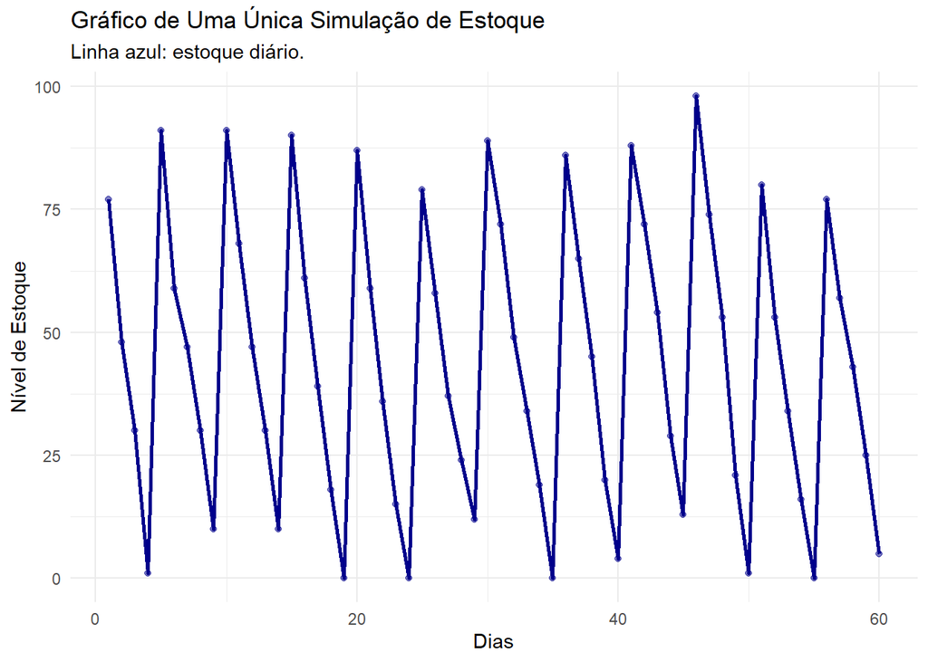

```r
grafico_simulacao_unica <- ggplot(df_simulacao_unica, aes(x = Dia, y = Estoque)) +
  geom_line(color = "darkblue", size = 1) +
  geom_point(color = "darkblue", alpha = 0.5) +
  labs(
    title = "Gráfico de Uma Única Simulação de Estoque",
    subtitle = "Linha azul: estoque diário.",
    y = "Nível de Estoque", x = "Dias"
  ) +
  theme_minimal()
print(grafico_simulacao_unica)
```

```r
# --------------------------------------------------------------------------
# 4. SIMULAÇÃO DE MONTE CARLO (1000 Réplicas)
# --------------------------------------------------------------------------

# Vetores para armazenar resultados físicos e financeiros
estoques_montecarlo <- matrix(0, nrow = simulacoes, ncol = dias_simulados)
custos_totais_mc <- numeric(simulacoes)
custos_pedido_mc <- numeric(simulacoes)
custos_holding_mc <- numeric(simulacoes)
custos_falta_mc <- numeric(simulacoes)
giro_estoque_mc <- numeric(simulacoes) # NOVO: Vetor para armazenar o giro

# Loop de execução
for (i in 1:simulacoes) {
  resultado <- simular_estoque_df(
    dias = dias_simulados, lambda = lambda_demanda, lead = lead_time,
    reord_point = ponto_ressuprimento, qtd_pedido = quantidade_pedido,
    estoque_ini = estoque_inicial, cost_order = custo_pedido,
    cost_hold = custo_holding_unit, cost_short = custo_falta_unit
  )

  # Armazenar resultados físicos e financeiros da simulação 'i'
  estoques_montecarlo[i, ] <- resultado$Estoque
  custos_pedido_mc[i] <- sum(resultado$CustoPedidoDia)
  custos_holding_mc[i] <- sum(resultado$CustoHoldingDia)
  custos_falta_mc[i] <- sum(resultado$CustoFaltaDia)
  custos_totais_mc[i] <- custos_pedido_mc[i] + custos_holding_mc[i] + custos_falta_mc[i]

  # NOVO: Calcular e armazenar o GIRO DE ESTOQUE para a simulação 'i'
  unidades_atendidas <- sum(resultado$Demanda) - sum(resultado$UnidadesFaltantes)
  estoque_medio_unidades <- mean(resultado$Estoque)

  # Evitar divisão por zero se o estoque médio for 0
  if (estoque_medio_unidades > 0) {
    giro_estoque_mc[i] <- unidades_atendidas / estoque_medio_unidades
  } else {
    giro_estoque_mc[i] <- 0
  }
}

# --------------------------------------------------------------------------
# 5. ANÁLISE DOS RESULTADOS AGREGADOS (FÍSICOS E FINANCEIROS)
# --------------------------------------------------------------------------

# 5.1. Análise do Estoque Físico Médio
estoque_medio <- colMeans(estoques_montecarlo)
estoque_sd <- apply(estoques_montecarlo, 2, sd)
df_plot_media <- data.frame(Dia = 1:dias_simulados, Estoque_Medio = estoque_medio, Estoque_SD = estoque_sd)

print("Gerando o gráfico do estoque médio...")
```

```
## [1] "Gerando o gráfico do estoque médio..."
```

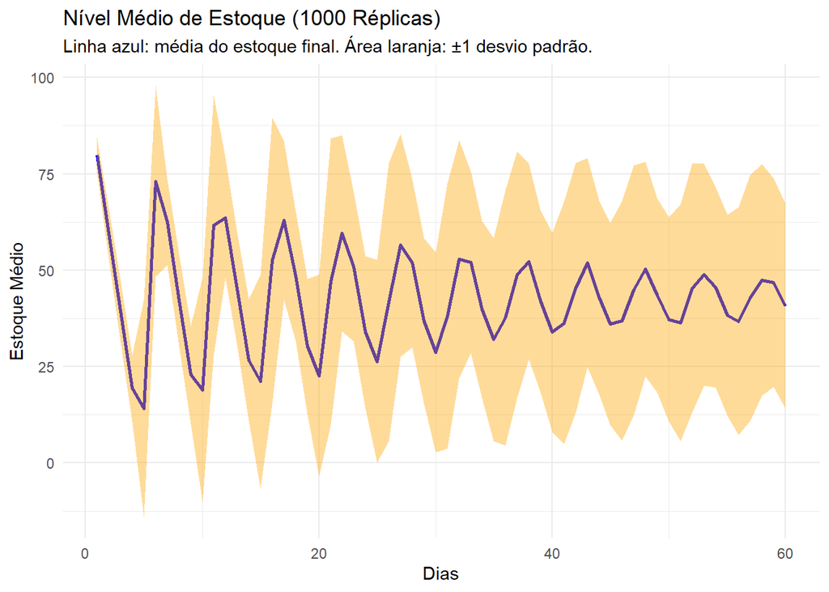

```r
grafico_media_monte_carlo <- ggplot(df_plot_media, aes(x = Dia, y = Estoque_Medio)) +
  geom_line(color = "blue", size = 1) +
  geom_ribbon(aes(ymin = Estoque_Medio - Estoque_SD, ymax = Estoque_Medio + Estoque_SD), fill = "orange", alpha = 0.4) +
  labs(
    title = "Nível Médio de Estoque (1000 Réplicas)",
    subtitle = "Linha azul: média do estoque final. Área laranja: ±1 desvio padrão.",
    y = "Estoque Médio", x = "Dias"
  ) +
  theme_minimal()
print(grafico_media_monte_carlo)
```

```r
# 5.2. Análise Financeira - Resumo e Distribuição de Custo
print("Resumo do Custo Total por Simulação (60 dias):")
```

```
## [1] "Resumo do Custo Total por Simulação (60 dias):"
```

```r
print(summary(custos_totais_mc))
```

```
##    Min. 1st Qu.  Median    Mean 3rd Qu.    Max.
##    1130    1234    1279    1284    1323    1602
```